# Integrate Download and EDA Functions

davegoblue

6/25/2020

## Background

METAR are hourly weather data collected at airports, including visibility, wind, temperature, dew point, precipitation, clouds, barometric pressure, and other features that may impact safe aviation.

Iowa State University has a great database of archived METAR data, stored in a manner that makes for easy, automated downloads in CSV format.

The files ‘WeatherDownload_202005_v002.Rmd’ and ‘WeatherEDA_202005_v002.Rmd’ contain functions for downloading weather files from the Iowa State server, running EDA, applying a constant format, and saving for further analysis.

The intent of this script is to take the key download and EDA functions, place them in a source file, and then run them as needed to output additional data.

#### *Sourcing Files*

Prior to sourcing functions, here are a few formatting helpers that are included here:

```r
# The functions sourced from the scripts use tidyverse and lubridate frequently
library(tidyverse)
library(lubridate)
```

```r
# Create a regex search string for METAR (the hourly time such as 53Z is pre-pended)
genMET <- ".*?(VRB|\\d{3})(\\d{2})(G\\d{2})?KT(.*?)(\\d{1,2}SM).*?\\s(M?\\d{2})/(M?\\d{2}).*?(A\\d{4}).*?RMK.*?(SLP\\d{3}).*?(T\\d{8})"

# Create the variable names that the above regex parses in to
labsMET <- c("METAR", "WindDir", "WindSpeed", "WindGust", "Dummy", "Visibility",
             "TempC", "DewC", "Altimeter", "SLP", "FahrC"
             )

# Expected columns for the downloaded METAR files
metType <- readr::cols(station=readr::col_character(),
                       valid=readr::col_datetime(),
                       tmpf=readr::col_double(),
                       dwpf=readr::col_double(),
                       relh=readr::col_double(),
                       drct=readr::col_double(),
                       sknt=readr::col_double(),
                       p01i=readr::col_character(),  # needs to handle 'T' for trace
                       alti=readr::col_double(),
                       mslp=readr::col_double(),
                       vsby=readr::col_double(),
                       gust=readr::col_double(),
                       skyc1=readr::col_character(),
                       skyc2=readr::col_character(),
                       skyc3=readr::col_character(),
                       skyc4=readr::col_character(),
                       skyl1=readr::col_double(),
                       skyl2=readr::col_double(),
                       skyl3=readr::col_double(),
                       skyl4=readr::col_double(),
                       wxcodes=readr::col_character(),
                       ice_accretion_1hr=readr::col_character(), # needs to handle 'T' for trace
                       ice_accretion_3hr=readr::col_character(), # needs to handle 'T' for trace
                       ice_accretion_6hr=readr::col_character(), # needs to handle 'T' for trace
                       peak_wind_gust=readr::col_double(),
                       peak_wind_drct=readr::col_double(),
                       peak_wind_time=readr::col_datetime(),
                       feel=readr::col_double(),
                       metar=readr::col_character()
                       )

# The main path for the files
filePath <- "./RInputFiles/ProcessedMETAR/"

# Descriptive names for key variables
varMapper <- c(WindDir="Wind Direction (degrees)",
               predomDir="General Prevailing Wind Direction",
               WindSpeed="Wind Speed (kts)",
               WindSpeed5="Wind Speed (kts), rounded to nearest 5 knots",
               Visibility="Visibility (SM)",
               TempC="Temperature (C)",
               DewC="Dew Point (C)",
               Altimeter="Altimeter (inches Hg)",
               Altimeter10="Altimeter (inches Hg), rounded to nearest 0.1 inHg",
               modSLP="Sea-Level Pressure (hPa)",
               TempF="Temperature (F)",
               DewF="Dew Point (F)",
               TempF5="Temperature (F), rounded to nearest 5 degrees",
               DewF5="Dew Point (F), rounded to nearest 5 degrees",
               cType1="First Cloud Layer Type",
               cLevel1="First Cloud Layer Height (ft)",
               month="Month",
               year="Year",
               wType="Greatest Sky Obscuration",
               day="Day of Month"
               )

# File name to city name mapper
cityNameMapper <- c(katl_2016="Atlanta, GA (2016)",
                    kbos_2016="Boston, MA (2016)",
                    kdca_2016="Washington, DC (2016)",
                    kden_2016="Denver, CO (2016)",
                    kdfw_2016="Dallas, TX (2016)",
                    kdtw_2016="Detroit, MI (2016)",
                    kewr_2016="Newark, NJ (2016)",
                    kgrb_2016="Green Bay, WI (2016)",
                    kgrr_2016="Grand Rapids, MI (2016)",
                    kiah_2016="Houston, TX (2016)",
                    kind_2016="Indianapolis, IN (2016)",
                    klas_2015="Las Vegas, NV (2015)",
                    klas_2016="Las Vegas, NV (2016)",
                    klas_2017="Las Vegas, NV (2017)",
                    klas_2018="Las Vegas, NV (2018)",
                    klas_2019="Las Vegas, NV (2019)",
                    klax_2016="Los Angeles, CA (2016)",
                    klnk_2016="Lincoln, NE (2016)",
                    kmia_2016="Miama, FL (2016)",
                    kmke_2016="Milwaukee, WI (2016)",
                    kmsn_2016="Madison, WI (2016)",
                    kmsp_2016="Minneapolis, MN (2016)",
                    kmsy_2015="New Orleans, LA (2015)",
                    kmsy_2016="New Orleans, LA (2016)",
                    kmsy_2017="New Orleans, LA (2017)",
                    kord_2014="Chicago, IL (2014)",
                    kord_2015="Chicago, IL (2015)",
                    kord_2016="Chicago, IL (2016)",
                    kord_2017="Chicago, IL (2017)",
                    kord_2018="Chicago, IL (2018)",
                    kphl_2016="Philadelphia, PA (2016)",
                    kphx_2016="Phoenix, AZ (2016)",
                    ksan_2015="San Diego, CA (2015)",
                    ksan_2016="San Diego, CA (2016)",
                    ksan_2017="San Diego, CA (2017)",
                    ksat_2016="San Antonio, TX (2016)",
                    ksea_2016="Seattle, WA (2016)",
                    ksfo_2016="San Francisco, CA (2016)",
                    ksjc_2016="San Jose, CA (2016)",
                    kstl_2016="Saint Louis, MO (2016)",
                    ktpa_2016="Tampa Bay, FL (2016)",
                    ktvc_2016="Traverse City, MI (2016)"
                    )

# Map of variable to chart name
mapChartVar <- c(p1Inches="1-hr Precip",
                 p36Inches="3-hr or 6-hr Precip",
                 p24Inches="24-hr Precip"
                 )
```

The relevant functions are stored in ‘WeatherDownloadFunctions_v001.R’ and ‘WeatherEDAFunctions_v001.R’. They are now sourced here:

```r
# Functions for downloading and saving a weather file
source("./WeatherDownloadFunctions_v001.R")
source("./WeatherEDAFunctions_v001.R")
```

Remaining cities from top 20 MSA are downloaded for 2016:

```r
# STEP 0: Define a named list of the stations and years for downloading
runFiles <- list(bos=c(2016),
                 sfo=c(2016),
                 sea=c(2016),
                 tpa=c(2016),
                 den=c(2016),
                 stl=c(2016)
                 )
```

```r
cat("\nRunning downloads by station for:\n")
```

```
##
## Running downloads by station for:
```

```r
sapply(runFiles, FUN=function(x) length(x))
```

```
## bos sfo sea tpa den stl
##   1   1   1   1   1   1
```

```r
# STEP 1: Download the raw data files from Iowa State
for (station in names(runFiles)) {
    for (year in runFiles[[station]]) {
        getASOSStationTime(stationID=str_to_upper(station), analysisYears=year, ovrWrite=TRUE)
    }
}
```

```
##
## Data for station BOS from 2015-12-31 to 2017-01-02 will download to ./RInputFiles/metar_kbos_2016.txt
##
##
## Data for station SFO from 2015-12-31 to 2017-01-02 will download to ./RInputFiles/metar_ksfo_2016.txt
##
##
## Data for station SEA from 2015-12-31 to 2017-01-02 will download to ./RInputFiles/metar_ksea_2016.txt
##
##
## Data for station TPA from 2015-12-31 to 2017-01-02 will download to ./RInputFiles/metar_ktpa_2016.txt
##
##
## Data for station DEN from 2015-12-31 to 2017-01-02 will download to ./RInputFiles/metar_kden_2016.txt
##
##
## Data for station STL from 2015-12-31 to 2017-01-02 will download to ./RInputFiles/metar_kstl_2016.txt
##
```

```r
cat("\nRunning main EDA process on key files\n")
```

```
##
## Running main EDA process on key files
```

```r
# STEP 2: Process and format the raw data files, and save as .rds
for (station in names(runFiles)) {
    for (year in runFiles[[station]]) {

        coreString <- paste0("metar_k", station, "_", as.character(year))

        cat("\nProcessing Airport:", station, "for year:", year)
        integrateProcessingMETAR(paste0("./RInputFiles/", coreString, ".txt"),
                                 startDay=paste0(as.character(year-1), "-12-31"),
                                 endDay=paste0(as.character(year+1), "-01-01"),
                                 genMET=genMET,
                                 labsMET=labsMET,
                                 saveLoc=paste0("./RInputFiles/ProcessedMETAR/", coreString, ".rds"),
                                 ovrWrite=TRUE,
                                 colTypes=metType,
                                 logFile=paste0("./RInputFiles/ProcessedMETAR/", coreString, ".log"),
                                 useNAforIncomplete=TRUE,
                                 showSLPGraph=FALSE
                                 )
        cat("\nFinished Processing Airport:", station, "in year:", year,"\n")

    }
}
```

```
##
## Processing Airport: bos for year: 2016
## Most common 10 times for file: ./RInputFiles/metar_kbos_2016.txt
## .
##  54Z  01Z  02Z  14Z  38Z  07Z  17Z  43Z  12Z  13Z
## 8711   38   37   37   37   35   34   34   33   32
##
## The most common Zulu time for ./RInputFiles/metar_kbos_2016.txt is 54Z
## Frequency is 86.1 % ( 8711 of 10114 )
##
## *** OBSERVATIONS EXPECTED BUT NOT RECORDED: 121 ***
##
##
## *** OBSERVATIONS RECORDED BUT NOT EXPECTED: 0 ***
##
## *** Are the extracted records unique? ***
##  TRUE
##
##
## *** Tentative Summary of Element Parsing ***
## .
## FALSE  TRUE
##     9  8702
```

```
##
##  *** Number of NA values ***
##      METAR    WindDir  WindSpeed   WindGust      Dummy Visibility      TempC
##          9          9          9       8711          9          9          9
##       DewC  Altimeter        SLP      FahrC      dtime  origMETAR      TempF
##          9          9          9          9          0          0          9
##       DewF
##          9
##
## Visibilities after correcting for fractions:
## 0.25  0.5 0.75    1 1.25  1.5 1.75    2  2.5    3    4    5    6    7    8    9
##   19   59   27   48   17   59   10   96   48  117   64   78   72  115  108   99
##   10 <NA>
## 7666    9
##
##
## Counts of wind gusts extracted:
##   14   15   16   17   18   19   20   21   22   23   24   25   26   27   28   29
##   16   39   84   98  114  153  150  161  133  125  119   98   77   91   83   52
##   30   31   32   33   34   35   36   37   38   39   40   41   42 <NA>
##   48   30   16   26   18    9   11   10    2    3    2    2    1 6940
##
##
## There are 2 issues with clouds data (see logfile):
##
## # A tibble: 7 x 2
##   wType     n
##   <fct> <int>
## 1 VV       41
## 2 OVC    2801
## 3 BKN    1576
## 4 SCT    1305
## 5 FEW    1664
## 6 CLR    1315
## 7 Error     9
##
## All Zulu times in the METAR are consistent with the datetime variable
##
## Over-writing existing file: ./RInputFiles/ProcessedMETAR/metar_kbos_2016.rds
##
```

[output cut: 10 more lines]

```
## Frequency is 90.7 % ( 8804 of 9710 )
##
## *** OBSERVATIONS EXPECTED BUT NOT RECORDED: 28 ***
##
##
## *** OBSERVATIONS RECORDED BUT NOT EXPECTED: 0 ***
##
## *** Are the extracted records unique? ***
##  TRUE
##
##
## *** Tentative Summary of Element Parsing ***
## .
## FALSE  TRUE
##    75  8729
```

```
##
##  *** Number of NA values ***
##      METAR    WindDir  WindSpeed   WindGust      Dummy Visibility      TempC
##         75         75         75       8804         75         75         75
##       DewC  Altimeter        SLP      FahrC      dtime  origMETAR      TempF
##         75         75         75         75          0          0         75
##       DewF
##         75
##
## Visibilities after correcting for fractions:
## 0.25  0.5 0.75    1 1.25  1.5 1.75    2  2.5    3    4    5    6    7    8    9
##    1    1    2    4    1    5   10   26   18   44   57   43   57   65  149  295
##   10 <NA>
## 7951   75
##
##
## Counts of wind gusts extracted:
##   14   15   16   17   18   19   20   21   22   23   24   25   26   27   28   29
##    4    4   10   12   24   28   48   45   57   58   60   58   52   42   42   32
##   30   31   32   33   34   35   36   37   38   39   40   41   42   43   44   46
##   42   31   26   22   26   17   16    4    9    7    5    4    3    1    1    2
##   47   49 <NA>
##    1    1 8010
##
##
## wType as created from clouds data is consistent
## # A tibble: 7 x 2
##   wType     n
##   <fct> <int>
## 1 VV        2
## 2 OVC    1594
## 3 BKN    2138
## 4 SCT    1192
## 5 FEW    2866
## 6 CLR     937
## 7 Error    75
##
## All Zulu times in the METAR are consistent with the datetime variable
##
## Over-writing existing file: ./RInputFiles/ProcessedMETAR/metar_ksfo_2016.rds
```

[output cut: 11 more lines]

```
## Frequency is 84.9 % ( 8813 of 10378 )
##
## *** OBSERVATIONS EXPECTED BUT NOT RECORDED: 19 ***
##
##
## *** OBSERVATIONS RECORDED BUT NOT EXPECTED: 0 ***
##
## *** Are the extracted records unique? ***
##  TRUE
##
##
## *** Tentative Summary of Element Parsing ***
## .
## FALSE  TRUE
##    21  8792
```

```
##
##  *** Number of NA values ***
##      METAR    WindDir  WindSpeed   WindGust      Dummy Visibility      TempC
##         21         21         21       8813         21         21         21
##       DewC  Altimeter        SLP      FahrC      dtime  origMETAR      TempF
##         21         21         21         21          0          0         21
##       DewF
##         21
##
## Visibilities after correcting for fractions:
## 0.125  0.25   0.5  0.75     1  1.25   1.5     2   2.5     3     4     5     6
##     7    18    18     6    18     7    18    40    12    65    68    75   114
##     7     8     9    10  <NA>
##   195   126   139  7866    21
##
##
## Counts of wind gusts extracted:
##   14   15   16   17   18   19   20   21   22   23   24   25   26   27   28   29
##    3   14   22   32   34   56   51   62   61   30   32   18   13   12   13    9
##   30   31   32   33   34   35   36   37   38   39   40   42 <NA>
##   11    5    1    4    7    3    1    2    2    1    2    1 8311
##
##
## There are 1 issues with clouds data (see logfile):
##
## # A tibble: 7 x 2
##   wType     n
##   <fct> <int>
## 1 VV       19
## 2 OVC    3341
## 3 BKN    2691
## 4 SCT     937
## 5 FEW     938
## 6 CLR     866
## 7 Error    21
##
## All Zulu times in the METAR are consistent with the datetime variable
##
## Over-writing existing file: ./RInputFiles/ProcessedMETAR/metar_ksea_2016.rds
##
```

[output cut: 10 more lines]

```
## Frequency is 88.2 % ( 8813 of 9992 )
##
## *** OBSERVATIONS EXPECTED BUT NOT RECORDED: 19 ***
##
##
## *** OBSERVATIONS RECORDED BUT NOT EXPECTED: 0 ***
##
## *** Are the extracted records unique? ***
##  TRUE
##
##
## *** Tentative Summary of Element Parsing ***
## .
## FALSE  TRUE
##    16  8797
```

```
##
##  *** Number of NA values ***
##      METAR    WindDir  WindSpeed   WindGust      Dummy Visibility      TempC
##         16         16         16       8813         16         16         16
##       DewC  Altimeter        SLP      FahrC      dtime  origMETAR      TempF
##         16         16         16         16          0          0         16
##       DewF
##         16
##
## Visibilities after correcting for fractions:
## 0.25  0.5    1 1.25  1.5 1.75    2  2.5    3    4    5    6    7    8    9   10
##   11   15   14    4    9    2    7   10   20   28   46   52   76  103  130 8270
## <NA>
##   16
##
##
## Counts of wind gusts extracted:
##   14   15   16   17   18   19   20   21   22   23   24   25   26   27   28   29
##   52   91  120  103  104   54   62   53   32   22   19   21    8   14    7    5
##   30   31   32   33   34   35   36   37   38   39 <NA>
##    8    1    5    3    2    5    2    1    1    1 8017
##
##
## wType as created from clouds data is consistent
## # A tibble: 7 x 2
##   wType     n
##   <fct> <int>
## 1 VV        2
## 2 OVC    1435
## 3 BKN    2522
## 4 SCT    1596
## 5 FEW    1733
## 6 CLR    1509
## 7 Error    16
##
## All Zulu times in the METAR are consistent with the datetime variable
##
## Over-writing existing file: ./RInputFiles/ProcessedMETAR/metar_ktpa_2016.rds
##
##
```

[output cut: 9 more lines]

```
## Frequency is 86.8 % ( 8820 of 10161 )
##
## *** OBSERVATIONS EXPECTED BUT NOT RECORDED: 12 ***
##
##
## *** OBSERVATIONS RECORDED BUT NOT EXPECTED: 0 ***
##
## *** Are the extracted records unique? ***
##  TRUE
##
##
## *** Tentative Summary of Element Parsing ***
## .
## FALSE  TRUE
##    27  8793
```

```
##
##  *** Number of NA values ***
##      METAR    WindDir  WindSpeed   WindGust      Dummy Visibility      TempC
##         27         27         27       8820         27         27         27
##       DewC  Altimeter        SLP      FahrC      dtime  origMETAR      TempF
##         27         27         27         27          0          0         27
##       DewF
##         27
##
## Visibilities after correcting for fractions:
##      0 0.0625  0.125   0.25    0.5   0.75      1   1.25    1.5   1.75      2
##      6      6     15     63     51     28     54     13      7     10     36
##    2.5      3      4      5      6      7      8      9     10   <NA>
##     12     23     36     29     39     41     46     85   8193     27
##
##
## Counts of wind gusts extracted:
##   14   15   16   17   18   19   20   21   22   23   24   25   26   27   28   29
##    8   28   41   36   34   28   48   48   43   35   49   30   42   35   41   29
##   30   31   32   33   34   35   36   37   38   39   40   41   42   43   44   45
##   21   23   10   12    8   11    9    8    4    8    2    1    2    1    2    2
##   46   47   51 <NA>
##    2    2    1 8116
##
##
## wType as created from clouds data is consistent
## # A tibble: 7 x 2
##   wType     n
##   <fct> <int>
## 1 VV       86
## 2 OVC     917
## 3 BKN    3125
## 4 SCT    1826
## 5 FEW    2049
## 6 CLR     790
## 7 Error    27
##
## All Zulu times in the METAR are consistent with the datetime variable
##
## Over-writing existing file: ./RInputFiles/ProcessedMETAR/metar_kden_2016.rds
```

[output cut: 11 more lines]

```
## Frequency is 83.9 % ( 8750 of 10435 )
##
## *** OBSERVATIONS EXPECTED BUT NOT RECORDED: 82 ***
##
##
## *** OBSERVATIONS RECORDED BUT NOT EXPECTED: 0 ***
##
## *** Are the extracted records unique? ***
##  TRUE
##
##
## *** Tentative Summary of Element Parsing ***
## .
## FALSE  TRUE
##    31  8719
```

```
##
##  *** Number of NA values ***
##      METAR    WindDir  WindSpeed   WindGust      Dummy Visibility      TempC
##         31         31         31       8750         31         31         31
##       DewC  Altimeter        SLP      FahrC      dtime  origMETAR      TempF
##         31         31         31         31          0          0         31
##       DewF
##         31
##
## Visibilities after correcting for fractions:
## 0.0625  0.125   0.25    0.5   0.75      1   1.25    1.5   1.75      2    2.5
##      3     12     14     13     13     18     12     16      7     20     29
##      3      4      5      6      7      8      9     10   <NA>
##     59     92    129    139    232    220    365   7326     31
##
##
## Counts of wind gusts extracted:
##   14   15   16   17   18   19   20   21   22   23   24   25   26   27   28   29
##   16   33   49   78   97   88  110   96  103   75   49   43   42   43   26   21
##   30   31   32   33   34   35   36   37   38   39   41   42 <NA>
##   26   15    9    4    4    1    1    4    1    1    2    1 7712
##
##
## wType as created from clouds data is consistent
## # A tibble: 7 x 2
##   wType     n
##   <fct> <int>
## 1 VV       20
## 2 OVC    2273
## 3 BKN    2509
## 4 SCT    1267
## 5 FEW    1413
## 6 CLR    1237
## 7 Error    31
##
## All Zulu times in the METAR are consistent with the datetime variable
##
## Over-writing existing file: ./RInputFiles/ProcessedMETAR/metar_kstl_2016.rds
##
##
## Finished Processing Airport: stl in year: 2016
```

Only the components of the EDA that are essential to checking the data and creating an output file for analysis are included.

Base EDA is run, with log files produced (pulls in a number of files previously downloaded, as well as the files recently downloaded):

```r
# Update the runFiles list for the stations to be run here
runFiles <- list(ord=c(2014, 2018),
                 las=c(2018, 2019),
                 atl=c(2016),
                 bos=c(2016),
                 dca=c(2016),
                 den=c(2016),
                 dfw=c(2016),
                 lax=c(2016),
                 mia=c(2016),
                 phl=c(2016),
                 phx=c(2016),
                 sat=c(2016),
                 sea=c(2016),
                 sfo=c(2016),
                 sjc=c(2016),
                 stl=c(2016),
                 tpa=c(2016)
                 )

# STEP 3a: Create the list of files to be run, process EDA, and output log files
fileNames <- character(0)
for (station in names(runFiles)) {
    for (year in runFiles[[station]]) {
        fileNames <- c(fileNames, paste0("k", station, "_", as.character(year)))
    }
}

cat("\nEDA process will be run for all of:\n\n", paste0(fileNames, collapse="\n"), "\n", sep="")
```

```
##
## EDA process will be run for all of:
##
## kord_2014
## kord_2018
## klas_2018
## klas_2019
## katl_2016
## kbos_2016
## kdca_2016
## kden_2016
## kdfw_2016
## klax_2016
## kmia_2016
## kphl_2016
## kphx_2016
## ksat_2016
## ksea_2016
## ksfo_2016
## ksjc_2016
## kstl_2016
## ktpa_2016
```

```r
for (fName in fileNames) {
    assign(fName, logAndPDFCombinedEDA(fName))
}
```

```
##
## RDS Name: metar_kord_2014.rds
## Log Name: metar_kord_2014_EDA.log
## PDF Name: metar_kord_2014_EDA.pdf
## Will use Chicago, IL (2014) as the description for metar_kord_2014.rds
##
##
## EDA PDF file is available at: ./RInputFiles/ProcessedMETAR/metar_kord_2014_EDA.pdf
##
## EDA log file is available at: ./RInputFiles/ProcessedMETAR/metar_kord_2014_EDA.log
```

```
##
## RDS Name: metar_kord_2018.rds
## Log Name: metar_kord_2018_EDA.log
## PDF Name: metar_kord_2018_EDA.pdf
## Will use Chicago, IL (2018) as the description for metar_kord_2018.rds
##
##
## EDA PDF file is available at: ./RInputFiles/ProcessedMETAR/metar_kord_2018_EDA.pdf
##
## EDA log file is available at: ./RInputFiles/ProcessedMETAR/metar_kord_2018_EDA.log
```

```
##
## RDS Name: metar_klas_2018.rds
## Log Name: metar_klas_2018_EDA.log
## PDF Name: metar_klas_2018_EDA.pdf
## Will use Las Vegas, NV (2018) as the description for metar_klas_2018.rds
##
##
## EDA PDF file is available at: ./RInputFiles/ProcessedMETAR/metar_klas_2018_EDA.pdf
##
## EDA log file is available at: ./RInputFiles/ProcessedMETAR/metar_klas_2018_EDA.log
```

```
##
## RDS Name: metar_klas_2019.rds
## Log Name: metar_klas_2019_EDA.log
## PDF Name: metar_klas_2019_EDA.pdf
## Will use Las Vegas, NV (2019) as the description for metar_klas_2019.rds
##
##
## EDA PDF file is available at: ./RInputFiles/ProcessedMETAR/metar_klas_2019_EDA.pdf
##
## EDA log file is available at: ./RInputFiles/ProcessedMETAR/metar_klas_2019_EDA.log
```

```
##
## RDS Name: metar_katl_2016.rds
## Log Name: metar_katl_2016_EDA.log
## PDF Name: metar_katl_2016_EDA.pdf
## Will use Atlanta, GA (2016) as the description for metar_katl_2016.rds
##
##
## EDA PDF file is available at: ./RInputFiles/ProcessedMETAR/metar_katl_2016_EDA.pdf
##
## EDA log file is available at: ./RInputFiles/ProcessedMETAR/metar_katl_2016_EDA.log
```

```
##
## RDS Name: metar_kbos_2016.rds
## Log Name: metar_kbos_2016_EDA.log
## PDF Name: metar_kbos_2016_EDA.pdf
## Will use Boston, MA (2016) as the description for metar_kbos_2016.rds
##
##
## EDA PDF file is available at: ./RInputFiles/ProcessedMETAR/metar_kbos_2016_EDA.pdf
##
## EDA log file is available at: ./RInputFiles/ProcessedMETAR/metar_kbos_2016_EDA.log
```

```
##
## RDS Name: metar_kdca_2016.rds
## Log Name: metar_kdca_2016_EDA.log
## PDF Name: metar_kdca_2016_EDA.pdf
## Will use Washington, DC (2016) as the description for metar_kdca_2016.rds
##
##
## EDA PDF file is available at: ./RInputFiles/ProcessedMETAR/metar_kdca_2016_EDA.pdf
##
## EDA log file is available at: ./RInputFiles/ProcessedMETAR/metar_kdca_2016_EDA.log
```

```
##
## RDS Name: metar_kden_2016.rds
## Log Name: metar_kden_2016_EDA.log
## PDF Name: metar_kden_2016_EDA.pdf
## Will use Denver, CO (2016) as the description for metar_kden_2016.rds
##
##
## EDA PDF file is available at: ./RInputFiles/ProcessedMETAR/metar_kden_2016_EDA.pdf
##
## EDA log file is available at: ./RInputFiles/ProcessedMETAR/metar_kden_2016_EDA.log
```

```
##
## RDS Name: metar_kdfw_2016.rds
## Log Name: metar_kdfw_2016_EDA.log
## PDF Name: metar_kdfw_2016_EDA.pdf
## Will use Dallas, TX (2016) as the description for metar_kdfw_2016.rds
##
##
## EDA PDF file is available at: ./RInputFiles/ProcessedMETAR/metar_kdfw_2016_EDA.pdf
##
## EDA log file is available at: ./RInputFiles/ProcessedMETAR/metar_kdfw_2016_EDA.log
```

```
##
## RDS Name: metar_klax_2016.rds
## Log Name: metar_klax_2016_EDA.log
## PDF Name: metar_klax_2016_EDA.pdf
## Will use Los Angeles, CA (2016) as the description for metar_klax_2016.rds
##
##
## EDA PDF file is available at: ./RInputFiles/ProcessedMETAR/metar_klax_2016_EDA.pdf
##
## EDA log file is available at: ./RInputFiles/ProcessedMETAR/metar_klax_2016_EDA.log
```

```
##
## RDS Name: metar_kmia_2016.rds
## Log Name: metar_kmia_2016_EDA.log
## PDF Name: metar_kmia_2016_EDA.pdf
## Will use Miama, FL (2016) as the description for metar_kmia_2016.rds
##
##
## EDA PDF file is available at: ./RInputFiles/ProcessedMETAR/metar_kmia_2016_EDA.pdf
##
## EDA log file is available at: ./RInputFiles/ProcessedMETAR/metar_kmia_2016_EDA.log
```

```
##
## RDS Name: metar_kphl_2016.rds
## Log Name: metar_kphl_2016_EDA.log
## PDF Name: metar_kphl_2016_EDA.pdf
## Will use Philadelphia, PA (2016) as the description for metar_kphl_2016.rds
##
##
## EDA PDF file is available at: ./RInputFiles/ProcessedMETAR/metar_kphl_2016_EDA.pdf
##
## EDA log file is available at: ./RInputFiles/ProcessedMETAR/metar_kphl_2016_EDA.log
```

```
##
## RDS Name: metar_kphx_2016.rds
## Log Name: metar_kphx_2016_EDA.log
## PDF Name: metar_kphx_2016_EDA.pdf
## Will use Phoenix, AZ (2016) as the description for metar_kphx_2016.rds
##
##
## EDA PDF file is available at: ./RInputFiles/ProcessedMETAR/metar_kphx_2016_EDA.pdf
##
## EDA log file is available at: ./RInputFiles/ProcessedMETAR/metar_kphx_2016_EDA.log
```

```
##
## RDS Name: metar_ksat_2016.rds
## Log Name: metar_ksat_2016_EDA.log
## PDF Name: metar_ksat_2016_EDA.pdf
## Will use San Antonio, TX (2016) as the description for metar_ksat_2016.rds
##
##
## EDA PDF file is available at: ./RInputFiles/ProcessedMETAR/metar_ksat_2016_EDA.pdf
##
## EDA log file is available at: ./RInputFiles/ProcessedMETAR/metar_ksat_2016_EDA.log
```

```
##
## RDS Name: metar_ksea_2016.rds
## Log Name: metar_ksea_2016_EDA.log
## PDF Name: metar_ksea_2016_EDA.pdf
## Will use Seattle, WA (2016) as the description for metar_ksea_2016.rds
##
##
## EDA PDF file is available at: ./RInputFiles/ProcessedMETAR/metar_ksea_2016_EDA.pdf
##
## EDA log file is available at: ./RInputFiles/ProcessedMETAR/metar_ksea_2016_EDA.log
```

```
##
## RDS Name: metar_ksfo_2016.rds
## Log Name: metar_ksfo_2016_EDA.log
## PDF Name: metar_ksfo_2016_EDA.pdf
## Will use San Francisco, CA (2016) as the description for metar_ksfo_2016.rds
##
##
## EDA PDF file is available at: ./RInputFiles/ProcessedMETAR/metar_ksfo_2016_EDA.pdf
##
## EDA log file is available at: ./RInputFiles/ProcessedMETAR/metar_ksfo_2016_EDA.log
```

```
##
## RDS Name: metar_ksjc_2016.rds
## Log Name: metar_ksjc_2016_EDA.log
## PDF Name: metar_ksjc_2016_EDA.pdf
## Will use San Jose, CA (2016) as the description for metar_ksjc_2016.rds
##
##
## EDA PDF file is available at: ./RInputFiles/ProcessedMETAR/metar_ksjc_2016_EDA.pdf
##
## EDA log file is available at: ./RInputFiles/ProcessedMETAR/metar_ksjc_2016_EDA.log
```

```
##
## RDS Name: metar_kstl_2016.rds
## Log Name: metar_kstl_2016_EDA.log
## PDF Name: metar_kstl_2016_EDA.pdf
## Will use Saint Louis, MO (2016) as the description for metar_kstl_2016.rds
##
##
## EDA PDF file is available at: ./RInputFiles/ProcessedMETAR/metar_kstl_2016_EDA.pdf
##
## EDA log file is available at: ./RInputFiles/ProcessedMETAR/metar_kstl_2016_EDA.log
```

```
##
## RDS Name: metar_ktpa_2016.rds
## Log Name: metar_ktpa_2016_EDA.log
## PDF Name: metar_ktpa_2016_EDA.pdf
## Will use Tampa Bay, FL (2016) as the description for metar_ktpa_2016.rds
##
##
## EDA PDF file is available at: ./RInputFiles/ProcessedMETAR/metar_ktpa_2016_EDA.pdf
##
## EDA log file is available at: ./RInputFiles/ProcessedMETAR/metar_ktpa_2016_EDA.log
```

```r
cat("\nRunning the rain data\n")
```

```
##
## Running the rain data
```

```r
# NEED TO FIX for Chicago 2014 rainfall - time recorded as 013 should be 0013
# Should fix function fnPrecip1-fnPrecip6 to handle this better
if (exists("kord_2014")) {
    kord_2014 <- kord_2014 %>%
        mutate(origMETAR=str_replace(origMETAR, pattern="RAB013 ", replacement="RAB0013 "))
}

# Run for rain, with logs and pdf sent to files
rain_List <- wrapPrecipTimes(fileNames,
                             pType="(?<!FZ)RA",
                             pExt="_RA",
                             pTypeName="rain",
                             writeLogFile="rain_extra0625_IntervalTimes.log",
                             writeLogPDF="rain_extra0625_IntervalTimes.pdf",
                             writeLogPath=filePath,
                             appendWriteFile=FALSE
                             )
```

```
##
## Precipitation times log file is available at: ./RInputFiles/ProcessedMETAR/rain_extra0625_IntervalTimes.log
##
## Summary of mismatch lengths after processing - see log file if needed
##              [,1]
## kord_2014_RA    0
## kord_2018_RA    0
## klas_2018_RA    0
## klas_2019_RA    0
## katl_2016_RA    0
## kbos_2016_RA    0
## kdca_2016_RA    0
## kden_2016_RA    0
## kdfw_2016_RA    0
## klax_2016_RA    0
## kmia_2016_RA    0
## kphl_2016_RA    0
## kphx_2016_RA    0
## ksat_2016_RA    0
## ksea_2016_RA    0
## ksfo_2016_RA    0
## ksjc_2016_RA    0
## kstl_2016_RA    0
## ktpa_2016_RA    0
##
## Precipitation times PDF file is available at: ./RInputFiles/ProcessedMETAR/rain_extra0625_IntervalTimes.pdf
##
## Will use minTime: 2016-01-01 and maxTime: 2016-12-31
```

```r
cat("\nRunning the snow data\n")
```

```
##
## Running the snow data
```

```r
# Run for snow, with logs and pdf sent to files
snow_List <- wrapPrecipTimes(fileNames,
                             pType="(?<!BL)SN",
                             pExt="_SN",
                             pTypeName="snow",
                             writeLogFile="snow_extra0625_IntervalTimes.log",
                             writeLogPDF="snow_extra0625_IntervalTimes.pdf",
                             writeLogPath=filePath,
                             appendWriteFile=FALSE
                             )
```

```
##
## Precipitation times log file is available at: ./RInputFiles/ProcessedMETAR/snow_extra0625_IntervalTimes.log
##
## Summary of mismatch lengths after processing - see log file if needed
##              [,1]
## kord_2014_SN    0
## kord_2018_SN    0
## klas_2018_SN    0
## klas_2019_SN    0
## katl_2016_SN    0
## kbos_2016_SN    0
## kdca_2016_SN    0
## kden_2016_SN    0
## kdfw_2016_SN    0
## klax_2016_SN    0
## kmia_2016_SN    0
## kphl_2016_SN    0
## kphx_2016_SN    0
## ksat_2016_SN    0
## ksea_2016_SN    0
## ksfo_2016_SN    0
## ksjc_2016_SN    0
## kstl_2016_SN    0
## ktpa_2016_SN    0
##
## Precipitation times PDF file is available at: ./RInputFiles/ProcessedMETAR/snow_extra0625_IntervalTimes.pdf
##
## Will use minTime: 2016-01-01 and maxTime: 2016-12-31
```

[output not shown]

```r
cat("\nRunning the thunder data\n")
```

```
##
## Running the thunder data
```

```r
# NEED TO FIX for Saint Louis 2016 thunder - time recorded as TSE57 should be TSE0757
# Should fix function fnPrecip1-fnPrecip6 to handle this better
if (exists("kstl_2016")) {
    kstl_2016 <- kstl_2016 %>%
        mutate(origMETAR=str_replace(origMETAR, pattern="TSE57 ", replacement="TSE0757 "))
}

# Run for thunder, with logs and pdf sent to files
thunder_List <- wrapPrecipTimes(fileNames,
                                pType="(?<!VC)TS",
                                pExt="_TS",
                                pTypeName="thunder",
                                writeLogFile="thunder_extra0625_IntervalTimes.log",
                                writeLogPDF="thunder_extra0625_IntervalTimes.pdf",
                                writeLogPath=filePath,
                                appendWriteFile=FALSE
                                )
```

```
##
## Precipitation times log file is available at: ./RInputFiles/ProcessedMETAR/thunder_extra0625_IntervalTimes.log
##
## Summary of mismatch lengths after processing - see log file if needed
##              [,1]
## kord_2014_TS    0
## kord_2018_TS    0
## klas_2018_TS    0
## klas_2019_TS    0
## katl_2016_TS    0
## kbos_2016_TS    0
## kdca_2016_TS    0
## kden_2016_TS    0
## kdfw_2016_TS    0
## klax_2016_TS    0
## kmia_2016_TS    0
## kphl_2016_TS    0
## kphx_2016_TS    0
## ksat_2016_TS    0
## ksea_2016_TS    0
## ksfo_2016_TS    0
## ksjc_2016_TS    0
## kstl_2016_TS    0
## ktpa_2016_TS    0
##
## Precipitation times PDF file is available at: ./RInputFiles/ProcessedMETAR/thunder_extra0625_IntervalTimes.pdf
##
## Will use minTime: 2016-01-01 and maxTime: 2016-12-31
```

Daily high-low temperatures and precipitation summaries are extracted, an integrated file is produced, and a predominant wind direction is added:

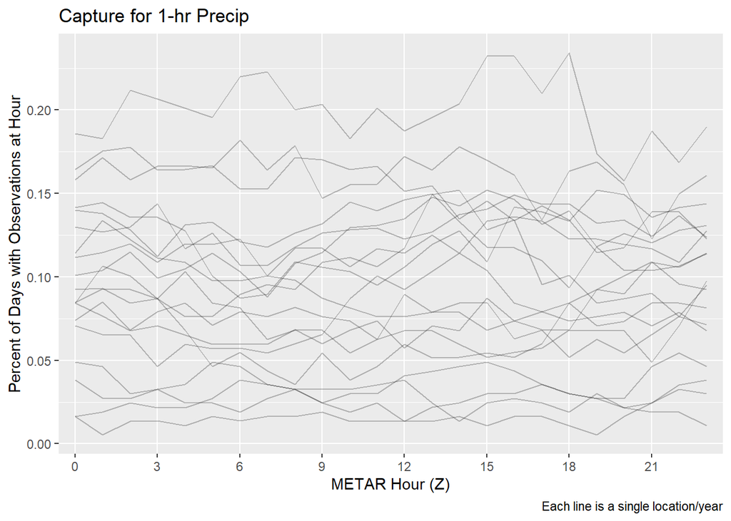

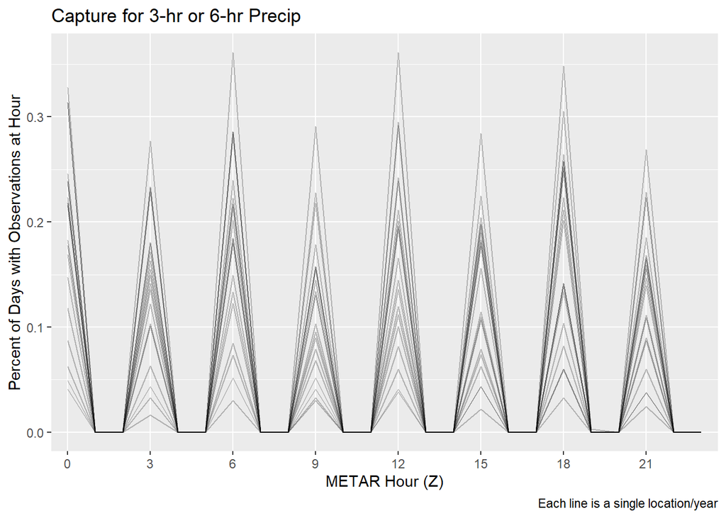

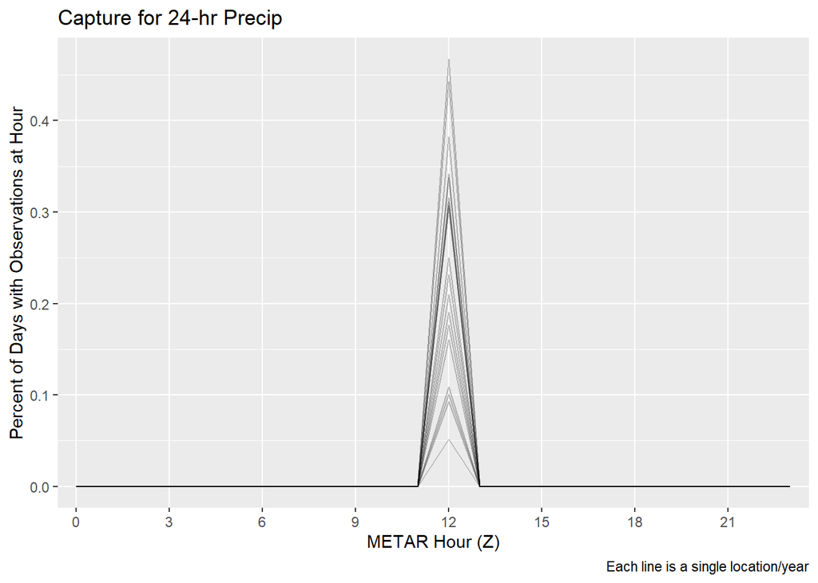

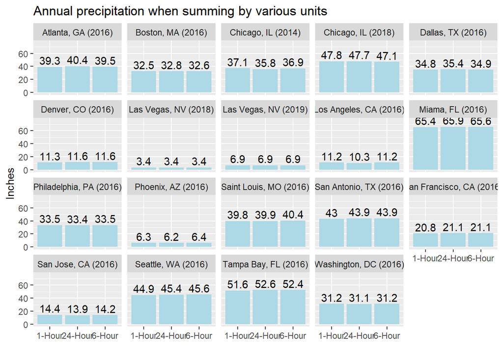

```r
# Function created to extract daily high-low temperatures
extractDailyHighLow <- function(x, f=getDailyHighLow, mapper=cityNameMapper, makePDF=NULL) {

    # FUNCTION ARGUMENTS:
    # x: a list of file names as a character string
    # f: the function to be called (getDailyHighLow was written for this purpose)
    # mapper: named vector for mapping file name to locale name
    # makePDF: the desired name of the PDF output (NULL means no output)

    # Extract high-low temperatures
    all_hilo <- map_dfr(.x=x, .f=f, .id="source") %>%
        mutate(source=x[as.integer(source)], locale=mapper[source]) %>%
        select(source, locale, everything())

    # Create the plot if makePDF is provided
    if (!is.null(makePDF)) {
        plotDailyHiLo(all_hilo, pdfName=makePDF)
    }

    # Return the high-low temperatures object
    all_hilo

}

# Get the high-low data for every file in fileNames
all_hilo <- extractDailyHighLow(fileNames)


extractDailyPrecipitation <- function(x,
                                      f=getPrecipAmount,
                                      cityMapper=cityNameMapper,
                                      chartMapper=mapChartVar,
                                      makePDF=NULL
                                      ) {

    # FUNCTION ARGUMENTS:
    # x: character vector of file names for getting daily precipitation
    # f: function for getting daily precipitation (getPrecipAmount was written for this)
    # cityMapper: mapping function for file name to locale name
    # chartMapper: mapping function for chart category to readable name
    # makePDF: file name for PDF output (NULL means do not create)

    # Extracted precipitation amounts
    all_pin <- map_dfr(.x=x, .f=f, .id="source") %>%
        mutate(source=x[as.integer(source)], locale=cityMapper[source]) %>%
        select(source, locale, everything())

    # Generate PDF for precipitation plots if requested
    if (!is.null(makePDF)) {
        plotPrecipNAHours(all_pin, mapper=chartMapper, pdfName=makePDF)
    }

    # Plot the time periods provided in chartNameMapper
    for (plotVar in names(chartMapper)) {
        # Counts of !is.na by hour
        p1 <- all_pin %>%
            mutate(hour=factor(lubridate::hour(lubridate::round_date(dtime, unit="hours"))),
                   notNA=!is.na(get(plotVar))
                   ) %>%
            group_by(source, hour) %>%
            summarize(pct=mean(notNA)) %>%
            ggplot(aes(x=hour, y=pct, group=source)) +
            geom_line(alpha=0.25) +
            labs(y="Percent of Days with Observations at Hour",
                 x="METAR Hour (Z)",
                 title=paste0("Capture for ", chartMapper[plotVar]),
                 caption="Each line is a single location/year"
                 ) +
            scale_x_discrete(breaks=seq(0, 23, by=3))
        print(p1)
    }

    # Sum precipitation by year for p1, p36 (using only 0Z-6Z-12Z-18Z), p24
    mod_pin <- all_pin %>%
        mutate(p1Inches=ifelse(is.na(p1Inches), 0, p1Inches),
               p36ok=lubridate::hour(lubridate::round_date(dtime, unit="hours")) %in% c(0, 6, 12, 18),
               p36Inches=ifelse(is.na(p36Inches) | !p36ok, 0, p36Inches),
               p24Inches=ifelse(is.na(p24Inches), 0, p24Inches)
               )

    # Create plot for annual precipitation sums by metric summed (1-hour, 6-hour, 24-hour)
    p2 <- mod_pin %>%
        group_by(locale) %>%
        summarize_if(is.numeric, sum) %>%
        rename(`1-Hour`=p1Inches, `6-Hour`=p36Inches, `24-Hour`=p24Inches) %>%
        pivot_longer(-locale, names_to="Unit", values_to="Inches") %>%
        ggplot(aes(x=Unit, y=Inches)) +
        geom_col(fill="lightblue") +
        geom_text(aes(label=round(Inches, 1), y=Inches+10)) +
        labs(title="Annual precipitation when summing by various units", x="") +
        facet_wrap(~locale)
    print(p2)

    # Return the precipitation object
    all_pin

}

# Get the daily precipitation data for every file in fileNames
all_pin <- extractDailyPrecipitation(fileNames)
```

```r
# Combine the relevant data files
allData <- combineProcessedFiles(fileNames)

# Show counts by sourceName
allData %>%
    count(source, sourceName)
```

```
## # A tibble: 19 x 3
##    source    sourceName                   n
##    <chr>     <chr>                    <int>
##  1 katl_2016 Atlanta, GA (2016)        8820
##  2 kbos_2016 Boston, MA (2016)         8711
##  3 kdca_2016 Washington, DC (2016)     8757
##  4 kden_2016 Denver, CO (2016)         8820
##  5 kdfw_2016 Dallas, TX (2016)         8820
##  6 klas_2018 Las Vegas, NV (2018)      8794
##  7 klas_2019 Las Vegas, NV (2019)      8804
##  8 klax_2016 Los Angeles, CA (2016)    8822
##  9 kmia_2016 Miama, FL (2016)          8822
## 10 kord_2014 Chicago, IL (2014)        8766
## 11 kord_2018 Chicago, IL (2018)        8785
## 12 kphl_2016 Philadelphia, PA (2016)   8818
## 13 kphx_2016 Phoenix, AZ (2016)        8821
## 14 ksat_2016 San Antonio, TX (2016)    8813
## 15 ksea_2016 Seattle, WA (2016)        8813
## 16 ksfo_2016 San Francisco, CA (2016)  8804
## 17 ksjc_2016 San Jose, CA (2016)       8818
## 18 kstl_2016 Saint Louis, MO (2016)    8750
## 19 ktpa_2016 Tampa Bay, FL (2016)      8813
```

```r
# Modify windDir so that it is just N, NE, E, SE, S, SW, W, NW, 000, Variable
modData <- allData %>%
    mutate(tempDir=ifelse(is.na(WindDir) | WindDir %in% c("000", "VRB"), -1, as.numeric(WindDir)),
           predomDir=factor(case_when(is.na(WindDir) ~ "Error",
                                      WindDir=="000" ~ "000",
                                      WindDir=="VRB" ~ "VRB",
                                      tempDir >= 337.5 ~ "N",
                                      tempDir <= 22.5 ~ "N",
                                      tempDir <= 67.5 ~ "NE",
                                      tempDir <= 112.5 ~ "E",
                                      tempDir <= 157.5 ~ "SE",
                                      tempDir <= 202.5 ~ "S",
                                      tempDir <= 247.5 ~ "SW",
                                      tempDir <= 292.5 ~ "W",
                                      tempDir <= 337.5 ~ "NW",
                                      TRUE ~ "Error"
                                      ),
                            levels=c("Error", "000", "VRB", "NE", "E", "SE", "S", "SW", "W", "NW", "N")
                            )
           )
# Show a glimpse of the processed data
glimpse(modData)
```

```
## Observations: 167,171
## Variables: 45
## $ source     <chr> "kord_2014", "kord_2014", "kord_2014", "kord_2014", "kor...
## $ METAR      <chr> "51Z 27007KT 4SM -SN OVC032 M12/M18 A3019 RMK AO2 SNB22 ...
## $ WindDir    <chr> "270", "300", "250", "290", "270", "310", "280", "300", ...
## $ WindSpeed  <int> 7, 5, 4, 7, 8, 8, 8, 10, 9, 7, 6, 8, 8, 9, 11, 10, 10, 1...
## $ WindGust   <dbl> NA, NA, NA, NA, NA, NA, NA, NA, NA, NA, NA, NA, NA, NA, ...
## $ Dummy      <chr> " ", " ", " ", " ", " ", " ", " ", " ", " ", " ", " ", "...
## $ Visibility <dbl> 4.0, 2.0, 4.0, 3.0, 4.0, 3.0, 9.0, 10.0, 10.0, 10.0, 10....
## $ TempC      <int> -12, -13, -13, -13, -13, -13, -13, -14, -14, -15, -16, -...
## $ DewC       <int> -18, -17, -17, -17, -17, -17, -18, -18, -19, -19, -20, -...
## $ Altimeter  <dbl> 30.19, 30.19, 30.17, 30.18, 30.18, 30.17, 30.16, 30.16, ...
## $ SLP        <int> 240, 238, 233, 235, 234, 229, 229, 227, 232, 233, 235, 2...
## $ FahrC      <chr> "T11221178", "T11281167", "T11281172", "T11331172", "T11...
## $ dtime      <dttm> 2013-12-31 00:51:00, 2013-12-31 01:51:00, 2013-12-31 02...
```

[output cut: 32 more lines]

Functions are then written to create cloud data (level, type, height by source and date-time) and relevant summaries (clouds of up to 12,000 feet, bucketed, with values for minimum height and minimum ceiling):

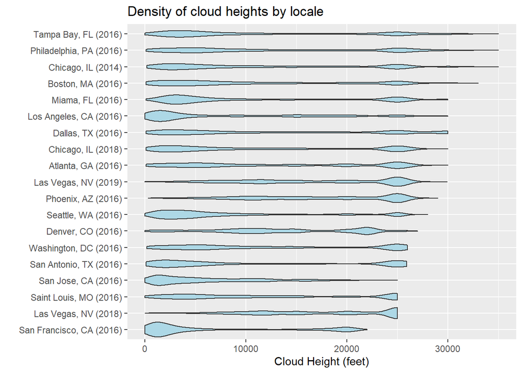

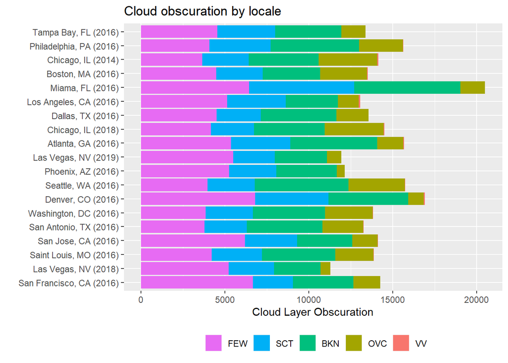

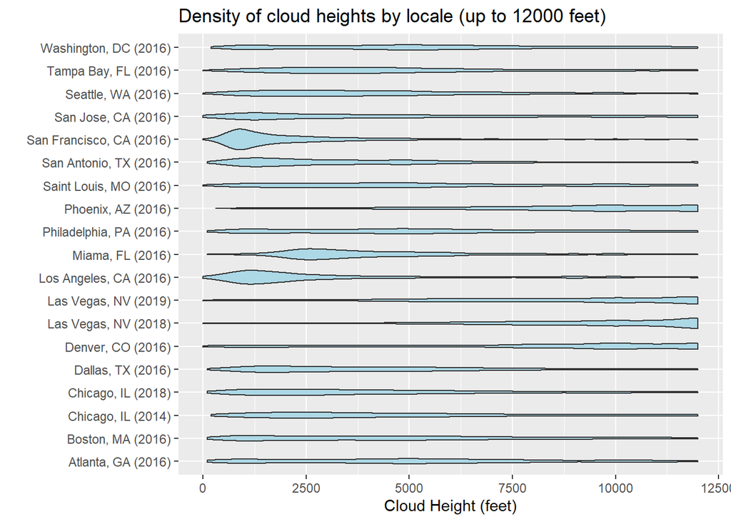

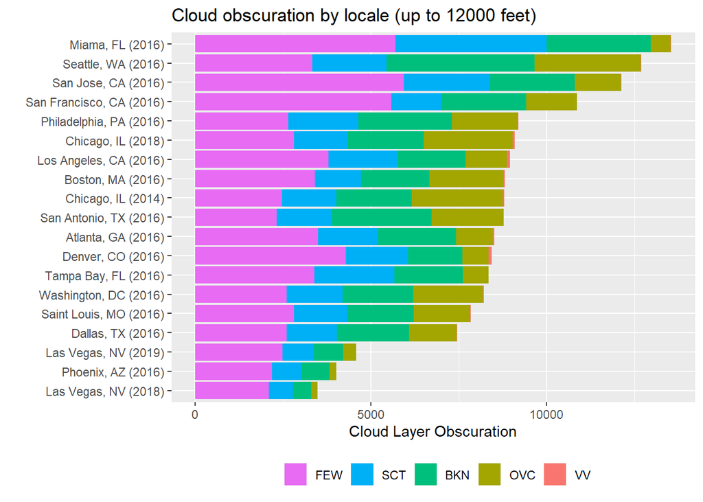

```r
createCloudData <- function(df,
                            fctLayers=c("VV", "OVC", "BKN", "SCT", "FEW"),
                            maxHeight=12000
                            ) {

    # FUNCTION ARGUMENTS:
    # df: the data frame or tibble of integrated weather station data
    # fctLayers: the factor levels for the cloud layers
    # maxHeight: a common maximum cloud height since different stations have different max
    #            (NULL means do not create chart)

    # Select the source, sourceName, dtime and cLevel variables; pivot cLevel down
    cLevels <- df %>%
        select(source, sourceName, dtime, starts_with("cLevel")) %>%
        pivot_longer(-c(source, sourceName, dtime), names_to="level", values_to="height") %>%
        mutate(level=as.integer(str_replace(level, pattern="cLevel", replacement="")))

    # Select the source, sourceName, dtime and cType variables; pivot cType down
    cTypes <- df %>%
        select(source, sourceName, dtime, starts_with("cType")) %>%
        pivot_longer(-c(source, sourceName, dtime), names_to="level", values_to="type") %>%
        mutate(level=as.integer(str_replace(level, pattern="cType", replacement="")))

    # Join the data
    cData <- cLevels %>%
        inner_join(cTypes, by=c("source", "sourceName", "dtime", "level"))

    # Confirm that no information was lost during the inner join
    if (nrow(cData) < max(nrow(cLevels), nrow(cTypes))) {
        cat("\ncLevels:", nrow(cLevels), "cTypes:", nrow(cTypes), "cData:", nrow(cData))
        stop("\nLost rows during the inner join - diagnose and fix\n")
    }

    # Plot cloud heights, using only non-NA
    p1 <- cData %>%
        filter(!is.na(height)) %>%
        ggplot(aes(x=fct_reorder(sourceName, height, .fun=max, na.rm=TRUE), y=height)) +
        geom_violin(fill="lightblue") +
        coord_flip() +
        labs(x="", y="Cloud Height (feet)", title="Density of cloud heights by locale")
    print(p1)

    # Plot cloud obscuration by locale
    p2 <- cData %>%
        filter(type!="") %>%
        mutate(type=factor(type, levels=fctLayers)) %>%
        ggplot(aes(x=fct_reorder(sourceName, height, .fun=max, na.rm=TRUE), fill=type)) +
        geom_bar(position="stack") +
        coord_flip() +
        labs(x="", y="Cloud Layer Obscuration", title="Cloud obscuration by locale") +
        scale_fill_discrete("", rev(fctLayers)) +
        theme(legend.position="bottom")
    print(p2)

    # Plot cloud heights and obscurations, up to a specified maximum (provided that it is not null)
    if (!is.null(maxHeight)) {
        # Cloud height violin plot
        p3 <- cData %>%
            filter(!is.na(height)) %>%
            filter(height <= maxHeight) %>%
            ggplot(aes(x=sourceName, y=height)) +
            geom_violin(fill="lightblue") +
            coord_flip() +
            labs(x="",
                 y="Cloud Height (feet)",
                 title=paste0("Density of cloud heights by locale (up to ", maxHeight, " feet)")
                 )
        print(p3)

        # Cloud obscuration plot
        p4 <- cData %>%
            filter(type!="") %>%
            filter(height <= maxHeight) %>%
            mutate(type=factor(type, levels=fctLayers)) %>%
            ggplot(aes(x=fct_reorder(sourceName, sourceName, .fun=length), fill=type)) +
            geom_bar(position="stack") +
            coord_flip() +
            labs(x="",
                 y="Cloud Layer Obscuration",
                 title=paste0("Cloud obscuration by locale (up to ", maxHeight, " feet)")
                 ) +
            scale_fill_discrete("", rev(fctLayers)) +
            theme(legend.position="bottom")
        print(p4)
    }

    # Return the cData object
    cData

}

# Create the cloud data object
cData <- createCloudData(modData)
```

```r
# Create the modified cloud data object (add CLR level at -100 if no clouds)
modCData <- cloudsLevel0(cData, maxHeight=12000, byVars=c("source", "sourceName", "dtime")) %>%
    mutate(type=factor(type, levels=c("VV", "OVC", "BKN", "SCT", "FEW", "CLR")))
modCData
```

```
## # A tibble: 330,918 x 6
##    source    sourceName         dtime               level height type
##    <chr>     <chr>              <dttm>              <dbl>  <dbl> <fct>
##  1 katl_2016 Atlanta, GA (2016) 2015-12-31 00:52:00     0   -100 CLR
##  2 katl_2016 Atlanta, GA (2016) 2015-12-31 00:52:00     1    300 FEW
##  3 katl_2016 Atlanta, GA (2016) 2015-12-31 00:52:00     2   4000 BKN
##  4 katl_2016 Atlanta, GA (2016) 2015-12-31 00:52:00     3   9000 OVC
##  5 katl_2016 Atlanta, GA (2016) 2015-12-31 01:52:00     0   -100 CLR
##  6 katl_2016 Atlanta, GA (2016) 2015-12-31 01:52:00     1    300 FEW
##  7 katl_2016 Atlanta, GA (2016) 2015-12-31 01:52:00     2   3800 BKN
##  8 katl_2016 Atlanta, GA (2016) 2015-12-31 01:52:00     3   9000 OVC
##  9 katl_2016 Atlanta, GA (2016) 2015-12-31 02:52:00     0   -100 CLR
## 10 katl_2016 Atlanta, GA (2016) 2015-12-31 02:52:00     1    300 FEW
## # ... with 330,908 more rows
```

```
## # A tibble: 7 x 3
##   ceilingType obscType     n
##   <fct>       <fct>    <int>
## 1 VV          VV         508
## 2 OVC         OVC      15528
## 3 BKN         OVC      11355
## 4 BKN         BKN      21513
## 5 CLR         SCT      18538
## 6 CLR         FEW      38160
## 7 CLR         CLR      61569
## # A tibble: 10 x 3
##    cloudType ceilingType     n
##    <fct>     <fct>       <int>
##  1 VV        VV            508
##  2 OVC       OVC         10942
```

[output cut: 23 more lines]

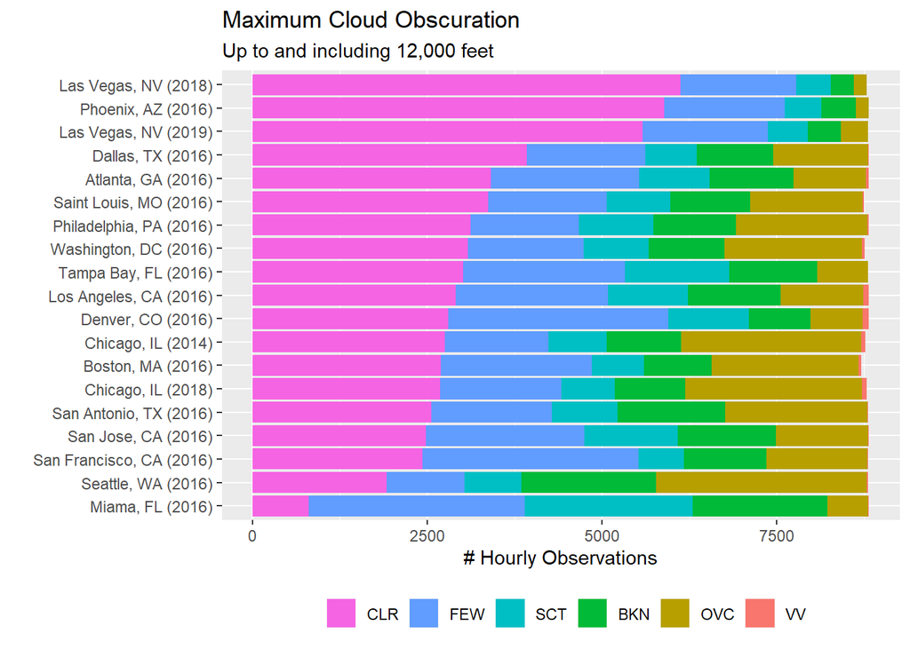

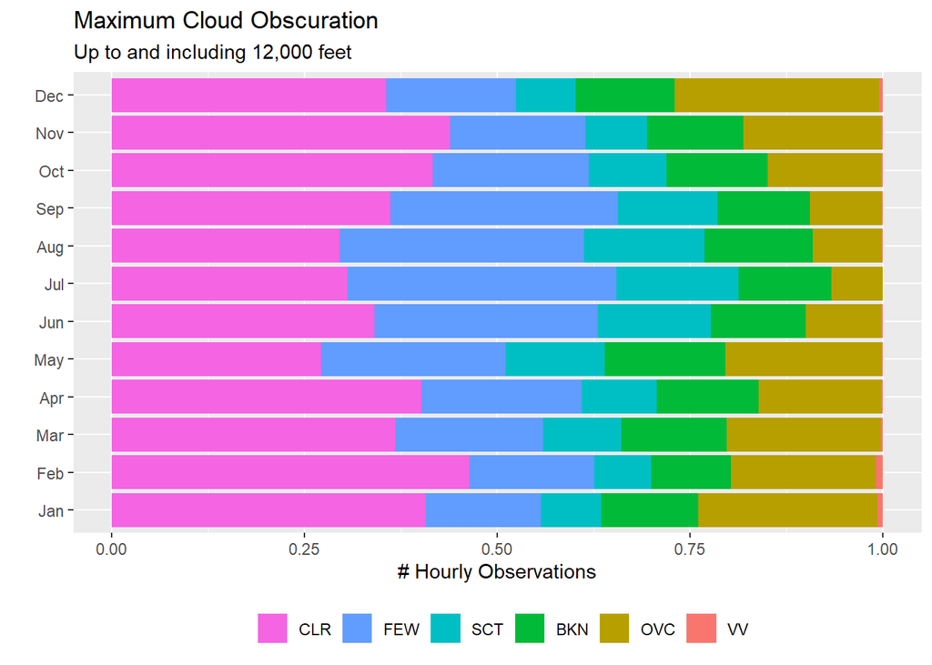

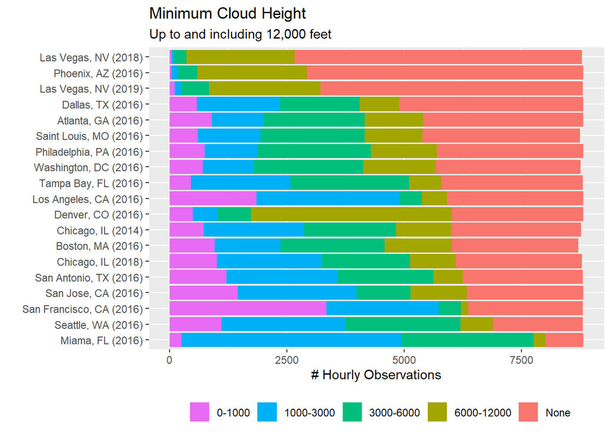

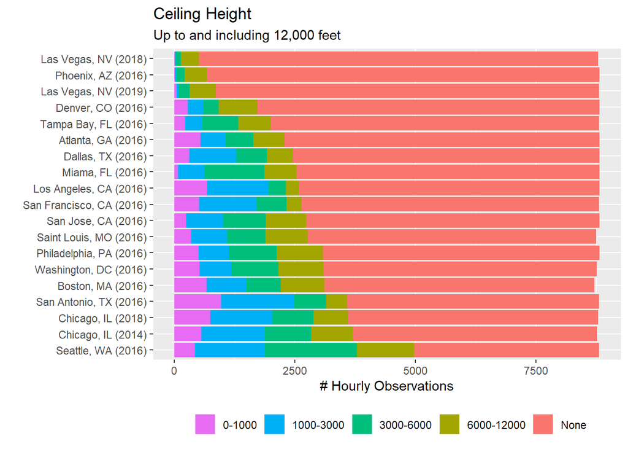

```r
# Helper function to convert cloud heights to levels (leave in main program; like a function argument)
helperHeightFactor <- function(x) {

    factor(case_when(x == -100 ~ "None",
                     x <= 1000 ~ "0-1000",
                     x <= 3000 ~ "1000-3000",
                     x <= 6000 ~ "3000-6000",
                     x <= 12000 ~ "6000-12000"
                     ),
           levels=c("None", "6000-12000", "3000-6000", "1000-3000", "0-1000")
           )

}


# Function to modify the clouds data and create relevant plots
plotAndModifyClouds <- function(df, helper=helperHeightFactor) {

    # FUNCTION ARGUMENTS:
    # df: the data frame or tibble holding the clouds data
    # helper: helper function for converting cloud heights to categorical factors

    # Checks for consistency
    df %>%
        count(ceilingType, obscType) %>%
        print()
    df %>%
        count(cloudType, ceilingType) %>%
        print()
    df %>%
        count(cloudType, obscType) %>%
        print()

    # Cloud obscuration by source
    plotMaxObsc(df,
                xVar="sourceName",
                fillVar="obscType",
                title="Maximum Cloud Obscuration",
                orderByVariable="obscType",
                orderByValue="CLR"
                )

    # Add month as both an integer and factor, and hour as an integer
    df <- df %>%
        mutate(month=lubridate::month(dtime),
               hour=lubridate::hour(dtime),
               monthfct=factor(month.abb[month], levels=month.abb[1:12])
               )

    # Cloud obscuration by month
    plotMaxObsc(df,
                xVar="monthfct",
                fillVar="obscType",
                title="Maximum Cloud Obscuration",
                posnBar="fill"
                )

    # Create the factored heights for minimum and ceiling
    df <- df %>%
        mutate(ceilFactor=helper(ceilingHeight),
               minCFactor=helper(cloudHeight)
               )

    # Create plots for the minimum cloud height and ceiling height
    plotMaxObsc(df,
                xVar="sourceName",
                fillVar="minCFactor",
                title="Minimum Cloud Height",
                orderByVariable="minCFactor",
                orderByValue="None"
                )

    plotMaxObsc(df,
                xVar="sourceName",
                fillVar="ceilFactor",
                title="Ceiling Height",
                orderByVariable="ceilFactor",
                orderByValue="None"
                )

    # Return the modified clouds object with month and hour
    df

}

# Get the key clouds data (heights and ceilings)
cloudSummary <- hgtCeilObsc(modCData, byVars=c("source", "sourceName", "dtime")) %>%
    plotAndModifyClouds()
```

A final file containing processed METAR, daily high/low and precipitation, hourly booleans by precipitation type, and cloud height buckets (minimum, minimum ceiling) is created and saved:

```r
# Function to add the boolean by type hourly precipitation data to finalData
addCurrentPrecip <- function(df, f=makeTibbleFromPrecip) {

    # FUNCTION ARGUMENTS:
    # df: data frame or tibble containing final, integrated data
    # f: function for mapping precipitation lists
    # CAVEAT: will use thunder_list, rain_list, and snow_list from global scope

    thunderData <- map_dfr(.x=list(thunder_List),
                           .f=f,
                           varName="isThunder"
                           )

    rainData <- map_dfr(.x=list(rain_List),
                        .f=f,
                        varName="isRain"
                        )

    snowData <- map_dfr(.x=list(snow_List),
                        .f=f,
                        varName="isSnow"
                        )

    # Inner join the precipitation data
    precipData <- rainData %>%
        inner_join(snowData, by=c("source", "dtime")) %>%
        inner_join(thunderData, by=c("source", "dtime"))

    # Confirm that no rows have been lost
    if (nrow(precipData) < max(nrow(rainData), nrow(snowData), nrow(thunderData))) {
        stop("\nPrecipitation data have mislaignment issues")
    }

    # Merge in to finalData
    if (nrow(df) != nrow(precipData)) {
        stop("\nPrecipitation data are not aligned with final data")
    }

    df <- df %>%
        inner_join(precipData, by=c("source", "dtime"))

    # Confirm that no rows have been lost
    if (nrow(df) < nrow(precipData)) {
        stop("\nPrecipitation data did not merge correctly with final data")
    }

    # Return the frame with precipitation boolean added
    df

}


# Function to add the temperature and precipitation summary data
addTempPrecipSummaries <- function(df, precipFile, tempFile) {

    # FUNCTION ARGUMENTS:
    # df: the main data frame or tibble
    # precipFile: the data frame or tibble containing the precipitation data
    # tempFile: the data frame or tibble containing the temperature data

    # Merge together the precipitation and temperature data
    precipTempData <- precipFile %>%
        select(source, dtime, p1Inches, p36Inches, p24Inches) %>%
        inner_join(select(tempFile, source, dtime, tempFHi, tempFLo),
                   by=c("source", "dtime")
                   )

    # Confirm that no rows have been lost
    if (nrow(precipTempData) < max(nrow(precipFile), nrow(tempFile))) {
        stop("\nPrecipitation and temperature summaries have mislaignment issues")
    }

    # Merge in to df
    if (nrow(df) != nrow(precipTempData)) {
        stop("\nPrecipitation and temperature summaries are not aligned with final data")
    }

    df <- df %>%
        inner_join(precipTempData, by=c("source", "dtime"))

    # Confirm that no rows have been lost
    if (nrow(df) < nrow(precipTempData)) {
        stop("\nPrecipitation and temperature summaries did not merge correctly with final data")
    }

    # Return the updated data frame
    df

}


# Function to add cloud summary
addCloudSummary <- function(df, cloudFile) {

    # FUNCTION ARGUMENTS:
    # df: the main data frame or tibble
    # cloudFile: the data frame or tibble containing the cloud summary data

    # Check for consistency in number of rows
    if (nrow(df) != nrow(cloudFile)) {
        stop("\nCloud summaries are not aligned with final data")
    }

    # Merge cloudFile in to df
    df <- df %>%
        inner_join(select(cloudFile, source, dtime, cloudHeight, cloudType, ceilingHeight, ceilingType),
                   by=c("source", "dtime")
                   ) %>%
        rename(minHeight=cloudHeight, minType=cloudType)

    # Confirm that no rows have been lost
    if (nrow(df) < nrow(cloudFile)) {
        stop("\nCloud summaries did not merge correctly with final data")
    }

    # Return the updated data frame
    df

}


# Function to check for duplicates and enforce a 'same-year' restriction
enforceYearCheck <- function(df) {

    # FUNCTION ARGUMENTS:
    # df: the data frame or tibble to be checked

    stationTime <- df %>%
        select(source, dtime) %>%
        mutate(station=str_sub(source, 1, 4)) %>%
        select(station, dtime)

    finalDups <- stationTime %>%
        duplicated()

    # Duplicates are expected if the same station occurs in succeeding years
    # This is driven by downloading/processing 1 day on either side of the year requested
    if (sum(finalDups) > 0) {
        cat("\nDuplicated records occur during:\n")
        stationTime %>%
            filter(finalDups) %>%
            count(station, date=lubridate::date(dtime)) %>%
            print()
    } else {
        cat("\nAll data are unique by station and dtime")
    }

    # Filter data to require that year in file name matches year in dtime
    filteredData <- df %>%
        filter(as.integer(str_sub(source, 6, -1))==year)

    # Report on summary statistics
    cat("\nEnforcing year restriction reduces data rows from:",
        nrow(df),
        "to:",
        nrow(filteredData),
        "\n"
        )

    # Return the filtered data file
    filteredData

}


# Select the appropriate variables from modData
# Add boolean precipitation by type and hour
# Add summaries for high-low temperature and precipitation amount
# Add summaries for clouds
# Require that the year in the file source match the year of dtime
finalData <- modData %>%
    select(source,
           locale=sourceName,
           dtime,
           origMETAR,
           year,
           monthint,
           month,
           day,
           WindDir,
           WindSpeed,
           WindGust,
           predomDir,
           Visibility,
           Altimeter,
           TempF,
           DewF,
           modSLP,
           starts_with("cType"),
           starts_with("cLevel")
           ) %>%
    addCurrentPrecip() %>%
    addTempPrecipSummaries(precipFile=all_pin, tempFile=all_hilo) %>%
    addCloudSummary(cloudFile=cloudSummary) %>%
    enforceYearCheck()
```

```
##
## Duplicated records occur during:
## # A tibble: 2 x 3
##   station date           n
##   <chr>   <date>     <int>
## 1 klas    2018-12-31    24
## 2 klas    2019-01-01    24
##
## Enforcing year restriction reduces data rows from: 167171 to: 166259
```

```r
# Report summary of the final file, and save as RDS
summary(finalData)
```

```
##     source             locale              dtime
##  Length:166259      Length:166259      Min.   :2014-01-01 00:51:00
##  Class :character   Class :character   1st Qu.:2016-04-01 10:51:00
##  Mode  :character   Mode  :character   Median :2016-07-26 12:54:00
##                                        Mean   :2016-10-06 04:58:48
##                                        3rd Qu.:2016-11-19 07:51:00
##                                        Max.   :2019-12-31 23:56:00
##
##   origMETAR              year         monthint          month
##  Length:166259      Min.   :2014   Min.   : 1.000   Mar    :14112
##  Class :character   1st Qu.:2016   1st Qu.: 4.000   Dec    :14105
##  Mode  :character   Median :2016   Median : 7.000   Aug    :14099
##                     Mean   :2016   Mean   : 6.516   Jan    :14097
##                     3rd Qu.:2016   3rd Qu.:10.000   Oct    :14093
##                     Max.   :2019   Max.   :12.000   May    :14089
##                                                     (Other):81664
##       day          WindDir            WindSpeed         WindGust
##  Min.   : 1.00   Length:166259      Min.   : 0.000   Min.   :13.00
##  1st Qu.: 8.00   Class :character   1st Qu.: 4.000   1st Qu.:18.00
##  Median :16.00   Mode  :character   Median : 7.000   Median :21.00
##  Mean   :15.76                      Mean   : 7.385   Mean   :22.03
##  3rd Qu.:23.00                      3rd Qu.:10.000   3rd Qu.:25.00
##  Max.   :31.00                      Max.   :43.000   Max.   :57.00
##                                     NA's   :512      NA's   :147534
##    predomDir       Visibility      Altimeter         TempF
##  S      :25424   Min.   : 0.00   Min.   :29.06   Min.   :-16.06
##  W      :23975   1st Qu.:10.00   1st Qu.:29.91   1st Qu.: 51.08
##  SW     :18363   Median :10.00   Median :30.02   Median : 64.04
##  E      :17450   Mean   : 9.57   Mean   :30.02   Mean   : 62.98
##  NW     :16803   3rd Qu.:10.00   3rd Qu.:30.13   3rd Qu.: 75.92
##  000    :15711   Max.   :10.00   Max.   :30.80   Max.   :395.60
##  (Other):48533   NA's   :512     NA's   :512     NA's   :512
##       DewF            modSLP          cType1             cType2
##  Min.   :-27.04   Min.   : 984.3   Length:166259      Length:166259
##  1st Qu.: 32.00   1st Qu.:1012.0   Class :character   Class :character
##  Median : 48.02   Median :1016.0   Mode  :character   Mode  :character
##  Mean   : 45.72   Mean   :1016.0
##  3rd Qu.: 59.00   3rd Qu.:1020.0
##  Max.   :210.92   Max.   :1045.4
##  NA's   :512      NA's   :512
```

[output cut: 33 more lines]

```
##  Min.   : -2.00   Min.   :-78.00   Min.   : -100   VV :  501   Min.   : -100
##  1st Qu.: 61.00   1st Qu.: 43.00   1st Qu.: -100   OVC:10839   1st Qu.: -100
##  Median : 74.00   Median : 55.00   Median : 1300   BKN:15664   Median : -100
##  Mean   : 72.51   Mean   : 54.12   Mean   : 2683   SCT:19381   Mean   : 1209
##  3rd Qu.: 86.00   3rd Qu.: 67.00   3rd Qu.: 4500   FEW:58588   3rd Qu.: 1000
##  Max.   :118.00   Max.   : 93.00   Max.   :12000   CLR:61286   Max.   :12000
##  NA's   :159350   NA's   :159350
##  ceilingType
##  VV :   501
##  OVC: 15394
##  BKN: 32648
##  SCT:     0
##  FEW:     0
##  CLR:117716
##
```

```r
saveRDS(finalData, "./RInputFiles/ProcessedMETAR/metar_postEDA_extra_20200626.rds")
```

The precipitation data is then integrated and saved:

```r
# Integrate the rain, snow, and thunder lists
allPrecipList <- list(rain=rain_List,
                      snow=snow_List,
                      thunder=thunder_List
                      )

# Provide a structure summary, and save as RDS
str(allPrecipList, max.level = 2)
```

```
## List of 3
##  $ rain   :List of 2
##   ..$ precipList  :List of 19
##   ..$ precipLength:Classes 'tbl_df', 'tbl' and 'data.frame': 228 obs. of  5 variables:
##  $ snow   :List of 2
##   ..$ precipList  :List of 19
##   ..$ precipLength:Classes 'tbl_df', 'tbl' and 'data.frame': 228 obs. of  5 variables:
##  $ thunder:List of 2
##   ..$ precipList  :List of 19
##   ..$ precipLength:Classes 'tbl_df', 'tbl' and 'data.frame': 228 obs. of  5 variables:
```

```r
saveRDS(allPrecipList, "./RInputFiles/ProcessedMETAR/metar_precipLists_extra_20200626.rds")
```

The clouds data are then integrated and saved:

```r
checkAndFilterClouds <- function(cloudFile, mainFile) {

    # FUNCTION ARGUMENTS:
    # cloudFile: the data frame or tibble containing the clouds data
    # mainFile: the data frame or tibble containing the final integrated data

    # Get the unique list
    modCDataTimes <- cloudFile %>%
        count(source, dtime)

    # In final, integrated data but not in clouds data
    mainFile %>%
        select(source, dtime) %>%
        anti_join(modCDataTimes, by=c("source", "dtime")) %>%
        print()

    # In modCDataTimes but not in main file
    modCDataTimes %>%
        select(source, dtime) %>%
        anti_join(mainFile, by=c("source", "dtime")) %>%
        count(source, date=lubridate::date(dtime)) %>%
        pivot_wider(source, names_from="date", values_from="n") %>%
        mutate_if(is.numeric, ~ifelse(is.na(.), 0, .)) %>%
        as.data.frame() %>%
        print()

    # Filter modCData so that year aligns as with fileteredData (return by default)
    modCData %>%
        filter(as.integer(str_sub(source, 6, 9))==lubridate::year(dtime))

}


# Run the function to get the filtered clouds data, then save as RDS
modCSaveData <- checkAndFilterClouds(cloudFile=modCData, mainFile=finalData)
```

```
## # A tibble: 0 x 2
## # ... with 2 variables: source <chr>, dtime <dttm>
##       source 2015-12-31 2017-01-01 2017-12-31 2019-01-01 2018-12-31 2020-01-01
## 1  katl_2016         24         24          0          0          0          0
## 2  kbos_2016         24         24          0          0          0          0
## 3  kdca_2016         24         24          0          0          0          0
## 4  kden_2016         24         24          0          0          0          0
## 5  kdfw_2016         24         24          0          0          0          0
## 6  klas_2018          0          0         24         24          0          0
## 7  klas_2019          0          0          0          0         24         24
## 8  klax_2016         24         24          0          0          0          0
## 9  kmia_2016         24         24          0          0          0          0
## 10 kord_2014          0          0          0          0          0          0
## 11 kord_2018          0          0         24         24          0          0
## 12 kphl_2016         24         24          0          0          0          0
```

[output cut: 27 more lines]

```r
saveRDS(modCSaveData, "./RInputFiles/ProcessedMETAR/metar_modifiedClouds_extra_20200626.rds")
```

Functions and analyses not run:

```r
# Fix for visibility > 10
cat("\nResetting Visibility > 10 to 10\n")
filteredData %>%
    filter(Visibility > 10)

summary(filteredData$Visibility)
filteredData <- filteredData %>%
    mutate(Visibility=ifelse(is.na(Visibility), NA, pmin(Visibility, 10)))
summary(filteredData$Visibility)


# Create rounded TempF and DewF in allData
allData <- allData %>%
    mutate(TempF5=5*round(round(TempF)/5),
           DewF5=5*round(round(DewF)/5),
           WindSpeed5=5*round(WindSpeed/5),
           Altimeter10=round(Altimeter, 1)
           )

# Save to an external PDF
pdf(paste0(filePath, "CrossLocaleCountsByMetric.pdf"))

# Counts by Metric for allData
plotcountsByMetric(allData,
                   mets=c("month", "year",
                          "WindDir", "WindSpeed5",
                          "Visibility", "Altimeter10",
                          "TempF5", "DewF5",
                          "wType"
                          ),
                   title="Comparisons Across Locales (red dots are the median)",
                   facetOn="sourceName",
                   showCentral=TRUE,
                   multiPageWrap=TRUE,
                   maxPerPage=12,
                   balancePages=TRUE
                   )

# Redirect to standard plotting
dev.off()


# Example for allData - using mixes of WindSpeed, Altimeter, TempF, DewF, TempC, DewC
numCorList <- list(c("TempC", "TempF"),
                   c("DewC", "DewF"),
                   c("TempF", "DewF"),
                   c("Altimeter", "WindSpeed"),
                   c("Altimeter", "TempF")
                   )

# Save to an external PDF
pdf(paste0(filePath, "CrossLocaleCorrelations.pdf"))

# Run the list through plotNumCor()
for (x in numCorList) {
    plotNumCor(allData,
               var1=x[1],
               var2=x[2],
               alpha=0.2,
               maxSize=3,
               subT="Red dashed line is the overall slope",
               diagnose=TRUE,
               facetOn="sourceName",
               showCentral=TRUE
               )
}

# Redirect to standard plotting
dev.off()



# Key factor variables include month, wType, predomDir
# Key numeric variables include WindSpeed, Altimeter, TempF, DewF, Visibility
fctNumList <- list(c("month", "WindSpeed"),
                   c("month", "Altimeter"),
                   c("month", "TempF"),
                   c("month", "DewF"),
                   c("month", "Visibility"),
                   c("wType", "WindSpeed"),
                   c("wType", "Altimeter"),
                   c("wType", "Visibility"),
                   c("predomDir", "WindSpeed"),
                   c("predomDir", "Altimeter"),
                   c("predomDir", "TempF"),
                   c("predomDir", "DewF")
                   )

# Save to an external PDF
pdf(paste0(filePath, "CrossLocaleFactorVsNumeric.pdf"))

for (x in fctNumList) {
    plotFactorNumeric(modData,
                      fctVar=x[1],
                      numVar=x[2],
                      subT="Red dots are the overall average",
                      showXLabel=FALSE,
                      diagnose=TRUE,
                      facetOn="sourceName",
                      showCentral=TRUE,
                      multiPageWrap=TRUE,
                      maxPerPage=12,
                      balancePages=TRUE
                      )
}

# Redirect to standard plotting
dev.off()


# Key factor variables include month, wType, predomDir
# Key numeric variables include WindSpeed, Altimeter, TempF, DewF, Visibility
fctNumListIQR <- list(c("month", "WindSpeed"),
                      c("month", "Altimeter"),
                      c("wType", "WindSpeed"),
                      c("predomDir", "Altimeter"),
                      c("predomDir", "TempF"),
                      c("predomDir", "DewF")
                      )

# Save to an external PDF
pdf(paste0(filePath, "CrossLocaleIQRFactorVsNumeric.pdf"))

for (x in fctNumListIQR) {
    plotMedianIQR(modData,
                  fctVar=x[1],
                  numVar=x[2],
                  subT="Red dots are the overall mid-quantile",
                  showXLabel=FALSE,
                  diagnose=TRUE,
                  facetOn="sourceName",
                  showCentral=TRUE,
                  multiPageWrap=TRUE,
                  maxPerPage=12,
                  balancePages=TRUE
                  )
}

# Redirect to standard plotting
dev.off()


plotMedianIQR(modData,
              fctVar="wType",
              numVar="WindSpeed",
              subT="Red dots are the overall mid-quantile",
              showXLabel=FALSE,
              diagnose=TRUE,
              facetOn="sourceName",
              showCentral=TRUE,
              ylimits=c(0, 15),
              multiPageWrap=TRUE,
              maxPerPage=12,
              balancePages=TRUE
              )


# Counts by Metric for predomDir using mod2016Data
plotcountsByMetric(modData,
                   mets=c("predomDir"),
                   title="Comparisons Across Locales (red dots are the median)",
                   facetOn="sourceName",
                   showCentral=TRUE,
                   multiPageWrap=TRUE,
                   maxPerPage=12,
                   balancePages=TRUE
                   )
```

```r
cityCloudList <- list(c("klas_2016", "ksan_2016", "kiah_2016", "kmsy_2016"),
                      c("kgrb_2016", "kgrr_2016", "kdtw_2016", "ktvc_2016"),
                      c("klnk_2016", "kmsp_2016", "kmsn_2016", "kind_2016"),
                      c("kmke_2016", "kord_2016", "kewr_2016")
                      )

for (x in cityCloudList) {
    cloudUse <- cloudSummary %>%
        filter(source %in% x)
    plotMaxObsc(cloudUse,
                xVar="monthfct",
                fillVar="obscType",
                title="Maximum Cloud Obscuration",
                facetOn="sourceName",
                posnBar="fill"
                )
}
```

```r
# Find the distances for obscType by locale vs. locale
obscDist <- findCloudDist(cloudSummary,
                          byVar=c("source", "sourceName"),
                          fctVar="obscType",
                          pivotVar="monthfct"
                          )
obscDist


plotCloudDist(obscDist, subT="Based on % of obscuration type by month")

# Run for minCFactor
findCloudDist(cloudSummary,
              byVar=c("source", "sourceName"),
              fctVar="minCFactor",
              pivotVar="monthfct"
              ) %>%
    plotCloudDist(subT="Based on % in each minimum cloud height bucket by month")

# Run for ceilFactor
findCloudDist(cloudSummary,
              byVar=c("source", "sourceName"),
              fctVar="ceilFactor",
              pivotVar="monthfct"
              ) %>%
    plotCloudDist(subT="Based on % in each ceiling height bucket by month")


set.seed(2006040940)

ceilDistData <- findCloudDist(cloudSummary,
                              byVar=c("source", "sourceName"),
                              fctVar="ceilFactor",
                              pivotVar="monthfct",
                              returnPivotOnly=TRUE
                              )

tibble::tibble(locale=ceilDistData$sourceName,
               cluster=kmeans(dist(ceilDistData[3:ncol(ceilDistData)]), centers=5, nstart=1000)$cluster
               ) %>%
    arrange(-cluster) %>%
    as.data.frame()


hclust(dist(ceilDistData[3:ncol(ceilDistData)]), method="complete") %>%
    plot(labels=ceilDistData$sourceName, cex=0.5, main="Hierarchical on Ceiling Height: method=complete")

hclust(dist(ceilDistData[3:ncol(ceilDistData)]), method="single") %>%
    plot(labels=ceilDistData$sourceName, cex=0.5, main="Hierarchical on Ceiling Height: method=single")


heightDistData <- findCloudDist(cloudSummary,
                                byVar=c("source", "sourceName"),
                                fctVar="minCFactor",
                                pivotVar="monthfct",
                                returnPivotOnly=TRUE
                                )

hclust(dist(heightDistData[3:ncol(heightDistData)]), method="complete") %>%
    plot(labels=heightDistData$sourceName, cex=0.5,
         main="Hierarchical on Minimum Cloud Height: method=complete"
         )

hclust(dist(heightDistData[3:ncol(heightDistData)]), method="single") %>%
    plot(labels=heightDistData$sourceName, cex=0.5,
         main="Hierarchical on Minimum Cloud Height: method=single"
         )


set.seed(2006041003)

cl5 <- tibble::tibble(locale=heightDistData$sourceName,
               cluster=kmeans(dist(heightDistData[3:ncol(heightDistData)]), centers=5, nstart=1000)$cluster
               ) %>%
    arrange(-cluster)

cl6 <- tibble::tibble(locale=heightDistData$sourceName,
               cluster=kmeans(dist(heightDistData[3:ncol(heightDistData)]), centers=6, nstart=1000)$cluster
               ) %>%
    arrange(-cluster)

cl7 <- tibble::tibble(locale=heightDistData$sourceName,
               cluster=kmeans(dist(heightDistData[3:ncol(heightDistData)]), centers=7, nstart=1000)$cluster
               ) %>%
    arrange(-cluster)


cl5 %>%
    rename(cl5=cluster) %>%
    inner_join(rename(cl6, cl6=cluster), by="locale") %>%
    inner_join(rename(cl7, cl7=cluster), by="locale") %>%
    as.data.frame()
```